# 데이터 과학 – 기초 통계

## 4.3 순차 분석(Sequential Analysis)

순차분석은 데이터를 수집하면서 반복적으로 유의성 통계검정을 수행하는 절차로 다음 세가지 중 하나를 택일한다.

1. 데이터 수집 중단: 통계적 유의성이 있어 귀무가설을 기각하고 실험을 중단.
2. 데이터 수집 중단: 통계적 유의성이 없어 귀무가설을 기각하지 못하고 실험을 중단.
3. 데이터 수집 계속: 결론을 내리기에 충분하지 못해서 실험을 계속진행.

[gsDesign](https://cran.r-project.org/web/packages/gsDesign/index.html) 팩키지를 사용해서 순차분석을 통해 실험에 대한 결론도 도출하고 표본크기도 산정한다.

`k = 4`는 3번 중간 분석을 수행하고 마지막 4번째 모든 데이터를 가지고 분석을 수행한다. `test.type`은 단축, 양측 검정 등을 설정하는 것이고, `alpha`는 유의수준, `beta`는 검정력과 관계되어 0.2는 검정력이 0.8을 나타내고 `sfu`는 Spending 함수로 여러 방법론이 있지만, `Pocock`을 지정하여 순차분석을 수행한다.

최대 가능 표본수가 1000개라고 가정하면 두집단이 되어 이를 `seq_analysis$timing`에 반영하면 중간중간 살펴봐야하는 표본을 산출할 수 있다.

```r
library(gsDesign)

# 1. 중단 규칙(stopping rule) ----
seq_analysis <- gsDesign(k = 4,
                         test.type = 2,
                         alpha = 0.05,
                         beta = 0.2,
                         sfu = "Pocock")

max_n <- 1000
max_n_per_group <- max_n / 2
stopping_points <- max_n_per_group * seq_analysis$timing
stopping_points
```

```
[1] 125 250 375 500
```

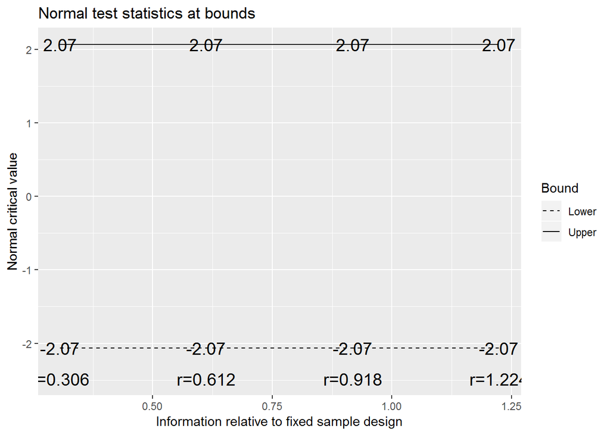

```r
plot(seq_analysis)
```

[^1]: [온라인 게임에서의 A/B 테스팅](http://boxnwhis.kr/2015/01/29/a_b_testing_online_games.html)
[^2]: [CLICK-THROUGH RATE PREDICTION – TOP-5 SOLUTION FOR THE AVAZU CONTEST](http://www.montis.pmf.ac.me/vol32/15.pdf)
[^3]: [A/B 테스트를 보완하는 Multi-Armed Bandit(MAB) 알고리즘](http://hub.zum.com/kimws/2586)
[^4]: [OReilly Webcasts: Bandit Algorithms for The Web](https://www.youtube.com/watch?v=BIP-VtmW_9M)
[^5]: [다중 슬롯머신 실험](https://support.google.com/analytics/answer/2844870?hl=ko&ref_topic=1745207)
[^6]: [CausalImpact](http://google.github.io/CausalImpact/CausalImpact.html)
[^7]: [Inferring causal impact using Bayesian structural time-series models](http://research.google.com/pubs/pub41854.html)
[^8]: [데이터 과학 – 기초 통계, 실무에서 자주 활용되는 검정(t-검정)](https://statkclee.github.io/statistics/stat-testing.html)